# Stat542: Logistic Regression

## The Convergence Issue

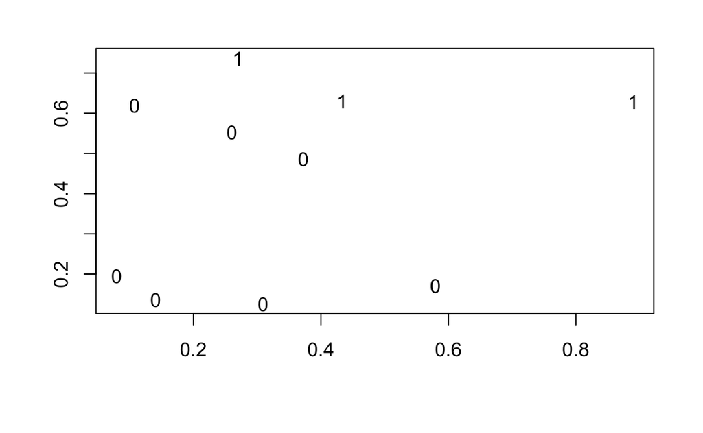

```r
x = matrix(runif(20), 10, 2)
y = ifelse(x[,1]+x[,2]>1, 1, 0);
plot(x[,1], x[,2], type="n", xlab="", ylab="");
text(x[,1], x[,2], y )
```

```r
myfit = glm(y~x, family=binomial)
```

```
glm.fit: fitted probabilities numerically 0 or 1 occurred
```

```r
summary(myfit)
```

```
Call:
glm(formula = y ~ x, family = binomial)

Deviance Residuals:
       Min          1Q      Median          3Q         Max
-1.218e-05  -2.110e-08  -2.110e-08   1.050e-08   1.228e-05

Coefficients:
            Estimate Std. Error z value Pr(>|z|)
(Intercept)   -207.0   373203.6  -0.001        1
x1             156.8   625495.6   0.000        1
x2             257.6   559810.1   0.000        1

(Dispersion parameter for binomial family taken to be 1)

    Null deviance: 1.2217e+01  on 9  degrees of freedom
Residual deviance: 4.1036e-10  on 7  degrees of freedom
AIC: 6

Number of Fisher Scoring iterations: 25
```

The likelihood for the logistic model doesn’t converge when data are separable: the MLE of beta would converge to infinity or negative-infinity. However, the separating line is still well-defined and we can still use the fitted model to do prediction, since 3*x1 + x2 > 2 is the same as 300*x1 + 100*x2 > 200

## Heart Data

The Coronary Risk‐Factor Study data involve 462 males between the ages of 15 and 64 from a heart‐disease high‐risk region of the Western Cape, South Africa. The response is “chd”, the presence (chd=1) or absence (chd=0) of coronary heart disease.

There are 9 covariates:

- sbp - systolic blood pressure
- tobacco - cumulative tobacco (kg)
- ldl - low densiity lipoprotein cholesterol
- adiposity
- famhist - family history of heart disease (Present, Absent)
- typea - type‐A behavior
- obesity
- alcohol - current alcohol consumption
- age - age at onset

### Fit a logistic model

```r
heart = read.table("https://web.stanford.edu/~hastie/ElemStatLearn//datasets/SAheart.data",
                   sep=",",head=T, row.names=1)
head(heart)
```

|  | sbp | tobacco | ldl | adiposity | famhist | typea | obesity | alcohol | age | chd |
| --- | --- | --- | --- | --- | --- | --- | --- | --- | --- | --- |
| 1 | 160 | 12.00 | 5.73 | 23.11 | Present | 49 | 25.30 | 97.20 | 52 | 1 |
| 2 | 144 | 0.01 | 4.41 | 28.61 | Absent | 55 | 28.87 | 2.06 | 63 | 1 |
| 3 | 118 | 0.08 | 3.48 | 32.28 | Present | 52 | 29.14 | 3.81 | 46 | 0 |
| 4 | 170 | 7.50 | 6.41 | 38.03 | Present | 51 | 31.99 | 24.26 | 58 | 1 |
| 5 | 134 | 13.60 | 3.50 | 27.78 | Present | 60 | 25.99 | 57.34 | 49 | 1 |
| 6 | 132 | 6.20 | 6.47 | 36.21 | Present | 62 | 30.77 | 14.14 | 45 | 0 |

```r
heartfull = glm(chd~., data=heart, family=binomial)
summary(heartfull)
```

```
Call:
glm(formula = chd ~ ., family = binomial, data = heart)

Deviance Residuals:
    Min       1Q   Median       3Q      Max
-1.7781  -0.8213  -0.4387   0.8889   2.5435

Coefficients:
                 Estimate Std. Error z value Pr(>|z|)
(Intercept)    -6.1507209  1.3082600  -4.701 2.58e-06 ***
sbp             0.0065040  0.0057304   1.135 0.256374
tobacco         0.0793764  0.0266028   2.984 0.002847 **
ldl             0.1739239  0.0596617   2.915 0.003555 **
adiposity       0.0185866  0.0292894   0.635 0.525700
famhistPresent  0.9253704  0.2278940   4.061 4.90e-05 ***
typea           0.0395950  0.0123202   3.214 0.001310 **
obesity        -0.0629099  0.0442477  -1.422 0.155095
alcohol         0.0001217  0.0044832   0.027 0.978350
age             0.0452253  0.0121298   3.728 0.000193 ***
---
Signif. codes:  0 ‘***’ 0.001 ‘**’ 0.01 ‘*’ 0.05 ‘.’ 0.1 ‘ ’ 1

(Dispersion parameter for binomial family taken to be 1)

    Null deviance: 596.11  on 461  degrees of freedom
Residual deviance: 472.14  on 452  degrees of freedom
AIC: 492.14

Number of Fisher Scoring iterations: 5
```

### Correlation among variables affects coefficients

How to interprete the coefficient associated with variable “obesity”? It is strange that having excessive body fat can actually lower your chance of having a heart disease?

```r
round(cor(data.matrix(heart)), dig=2)
```

```
            sbp tobacco   ldl adiposity famhist typea obesity
sbp        1.00    0.21  0.16      0.36    0.09 -0.06    0.24
tobacco    0.21    1.00  0.16      0.29    0.09 -0.01    0.12
ldl        0.16    0.16  1.00      0.44    0.16  0.04    0.33
adiposity  0.36    0.29  0.44      1.00    0.18 -0.04    0.72
famhist    0.09    0.09  0.16      0.18    1.00  0.04    0.12
typea     -0.06   -0.01  0.04     -0.04    0.04  1.00    0.07
obesity    0.24    0.12  0.33      0.72    0.12  0.07    1.00
alcohol    0.14    0.20 -0.03      0.10    0.08  0.04    0.05
age        0.39    0.45  0.31      0.63    0.24 -0.10    0.29
chd        0.19    0.30  0.26      0.25    0.27  0.10    0.10
          alcohol   age  chd
sbp          0.14  0.39 0.19
tobacco      0.20  0.45 0.30
ldl         -0.03  0.31 0.26
adiposity    0.10  0.63 0.25
famhist      0.08  0.24 0.27
typea        0.04 -0.10 0.10
obesity      0.05  0.29 0.10
alcohol      1.00  0.10 0.06
age          0.10  1.00 0.37
chd          0.06  0.37 1.00
```

### Compute deviances

- What’s null deviance?
- What’s residual deviance?

```r
phat=heartfull$fitted.values;
-2*(sum(log(phat[heart$chd==1])) +
  sum(log(1-phat[heart$chd==0])))
```

```
[1] 472.14
```

```r
table(heart$chd)
```

```
  0   1
302 160
```

```r
p0hat = rep(mean(heart$chd), length(heart$chd))  # 160/(160+302)
-2*(sum(log(p0hat[heart$chd==1])) +
  sum(log(1-p0hat[heart$chd==0])))
```

```
[1] 596.1084
```

#### Stepwise Mode Selection with AIC and BIC.

The two procedures happen to return the same model.

```r
heartstepA = step(heartfull, scope=list(upper=~., lower=~1))
```

```
Start:  AIC=492.14
chd ~ sbp + tobacco + ldl + adiposity + famhist + typea + obesity +
    alcohol + age

            Df Deviance    AIC
- alcohol    1   472.14 490.14
- adiposity  1   472.55 490.55
- sbp        1   473.44 491.44
<none>           472.14 492.14
- obesity    1   474.23 492.23
- ldl        1   481.07 499.07
- tobacco    1   481.67 499.67
- typea      1   483.05 501.05
- age        1   486.53 504.53
- famhist    1   488.89 506.89

Step:  AIC=490.14
chd ~ sbp + tobacco + ldl + adiposity + famhist + typea + obesity +
    age

            Df Deviance    AIC
- adiposity  1   472.55 488.55
- sbp        1   473.47 489.47
<none>           472.14 490.14
- obesity    1   474.24 490.24
+ alcohol    1   472.14 492.14
- ldl        1   481.15 497.15
- tobacco    1   482.06 498.06
- typea      1   483.06 499.06
- age        1   486.64 502.64
- famhist    1   488.99 504.99

Step:  AIC=488.55
chd ~ sbp + tobacco + ldl + famhist + typea + obesity + age

            Df Deviance    AIC
- sbp        1   473.98 487.98
<none>           472.55 488.55
- obesity    1   474.65 488.65
+ adiposity  1   472.14 490.14
```

[output cut: 21 more lines]

```

Step:  AIC=487.69
chd ~ tobacco + ldl + famhist + typea + age

            Df Deviance    AIC
<none>           475.69 487.69
+ obesity    1   473.98 487.98
+ sbp        1   474.65 488.65
+ adiposity  1   475.44 489.44
+ alcohol    1   475.65 489.65
- ldl        1   484.71 494.71
- typea      1   485.44 495.44
- tobacco    1   486.03 496.03
- famhist    1   492.09 502.09
- age        1   502.38 512.38
```

```r
summary(heartstepA)
```

```
Call:
glm(formula = chd ~ tobacco + ldl + famhist + typea + age, family = binomial,
    data = heart)

Deviance Residuals:
    Min       1Q   Median       3Q      Max
-1.9165  -0.8054  -0.4430   0.9329   2.6139

Coefficients:
               Estimate Std. Error z value Pr(>|z|)
(Intercept)    -6.44644    0.92087  -7.000 2.55e-12 ***
tobacco         0.08038    0.02588   3.106  0.00190 **
ldl             0.16199    0.05497   2.947  0.00321 **
famhistPresent  0.90818    0.22576   4.023 5.75e-05 ***
typea           0.03712    0.01217   3.051  0.00228 **
age             0.05046    0.01021   4.944 7.65e-07 ***
---
Signif. codes:  0 ‘***’ 0.001 ‘**’ 0.01 ‘*’ 0.05 ‘.’ 0.1 ‘ ’ 1

(Dispersion parameter for binomial family taken to be 1)

    Null deviance: 596.11  on 461  degrees of freedom
Residual deviance: 475.69  on 456  degrees of freedom
AIC: 487.69

Number of Fisher Scoring iterations: 5
```

```r
n=dim(heart)[1]
heartstepB = step(heartfull, scope=list(upper=~., lower=~1), trace = 0, k=log(n))
summary(heartstepB)
```

```
Call:
glm(formula = chd ~ tobacco + ldl + famhist + typea + age, family = binomial,
    data = heart)

Deviance Residuals:
    Min       1Q   Median       3Q      Max
-1.9165  -0.8054  -0.4430   0.9329   2.6139

Coefficients:
               Estimate Std. Error z value Pr(>|z|)
(Intercept)    -6.44644    0.92087  -7.000 2.55e-12 ***
tobacco         0.08038    0.02588   3.106  0.00190 **
ldl             0.16199    0.05497   2.947  0.00321 **
famhistPresent  0.90818    0.22576   4.023 5.75e-05 ***
typea           0.03712    0.01217   3.051  0.00228 **
age             0.05046    0.01021   4.944 7.65e-07 ***
---
Signif. codes:  0 ‘***’ 0.001 ‘**’ 0.01 ‘*’ 0.05 ‘.’ 0.1 ‘ ’ 1

(Dispersion parameter for binomial family taken to be 1)

    Null deviance: 596.11  on 461  degrees of freedom
Residual deviance: 475.69  on 456  degrees of freedom
AIC: 487.69

Number of Fisher Scoring iterations: 5
```

### Estimation and prediction

Estimation (probability of being 1) on the training samples.

```r
phat=heartstepA$fitted.values;
mypred = (phat>0.5)
table(heart$chd, mypred)
```

```
   mypred
    FALSE TRUE
  0   256   46
  1    73   87
```

Consider the following three males with the same value on all other predictors except age: min, max, and median. What’s the estimated chance of getting heart disease for each of them?

```r
testsamples = heart[c(1, 1, 1),]
testsamples
```

|  | sbp | tobacco | ldl | adiposity | famhist | typea | obesity | alcohol | age | chd |
| --- | --- | --- | --- | --- | --- | --- | --- | --- | --- | --- |
| 1 | 160 | 12 | 5.73 | 23.11 | Present | 49 | 25.3 | 97.2 | 52 | 1 |
| 1.1 | 160 | 12 | 5.73 | 23.11 | Present | 49 | 25.3 | 97.2 | 52 | 1 |
| 1.2 | 160 | 12 | 5.73 | 23.11 | Present | 49 | 25.3 | 97.2 | 52 | 1 |

```r
testsamples$age = c(min(heart$age), median(heart$age), max(heart$age))
testsamples
```

|  | sbp | tobacco | ldl | adiposity | famhist | typea | obesity | alcohol | age | chd |
| --- | --- | --- | --- | --- | --- | --- | --- | --- | --- | --- |
| 1 | 160 | 12 | 5.73 | 23.11 | Present | 49 | 25.3 | 97.2 | 15 | 1 |
| 1.1 | 160 | 12 | 5.73 | 23.11 | Present | 49 | 25.3 | 97.2 | 45 | 1 |
| 1.2 | 160 | 12 | 5.73 | 23.11 | Present | 49 | 25.3 | 97.2 | 64 | 1 |

- predict log-odds
- predict probabilities

```r
predict(heartstepA, newdata=testsamples)
```

```
         1        1.1        1.2
-1.0700021  0.4438094  1.4025567
```

```r
predict(heartstepA, newdata=testsamples, type="response")
```

```
        1       1.1       1.2
0.2554027 0.6091664 0.8025893
```

### Model selection with Lasso

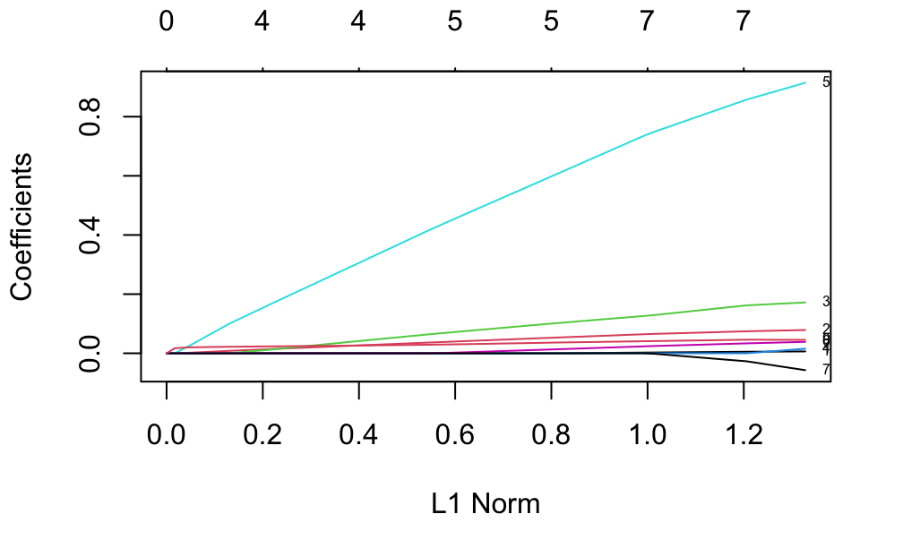

```r
library(glmnet)
p = dim(heart)[2]
X=data.matrix(heart[,-p]);
Y=heart[,p];
heart.l1=glmnet(X,Y,family="binomial",alpha=1)
plot(heart.l1,label=TRUE)
```

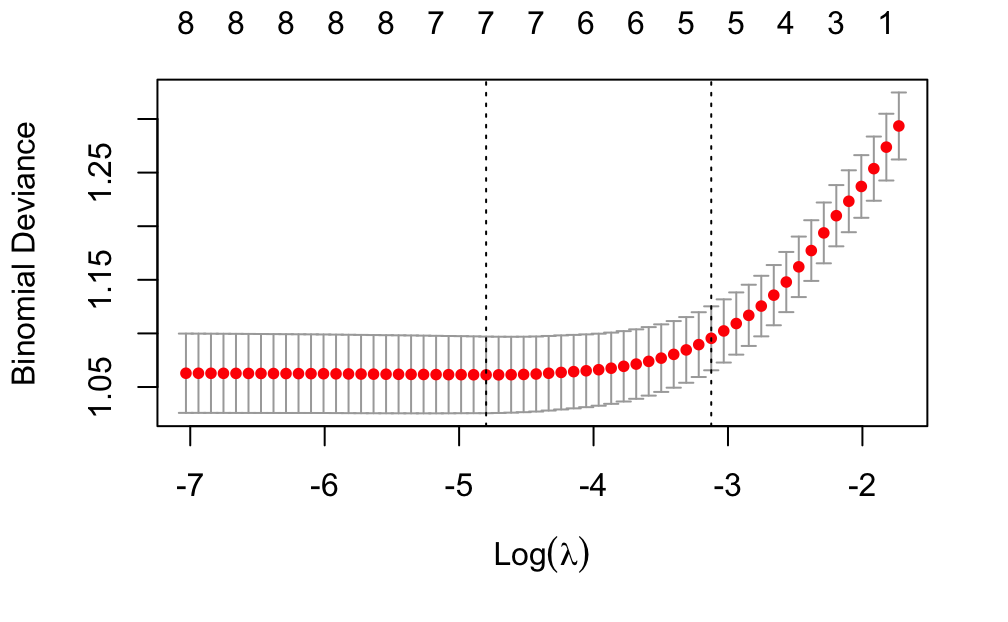

```r
heart.cv = cv.glmnet(X, Y, family="binomial",alpha=1)
plot(heart.cv)
```

```r
heart.cv$lambda.min
```

```
[1] 0.008236941
```

```r
heart.cv$lambda.1se
```

```
[1] 0.04395808
```

```r
predict(heart.cv, lambda=heart.cv$lambda.1se, type="coefficients")
```

```
10 x 1 sparse Matrix of class "dgCMatrix"
                       1
(Intercept) -3.781803152
sbp          .
tobacco      0.045237374
ldl          0.084175103
adiposity    .
famhist      0.516247338
typea        0.006829911
obesity      .
alcohol      .
age          0.032644419
```

## Challenger O-Ring Data

The motivation for collecting this database was the explosion of the USA Space Shuttle Challenger on 28 January 1986. The explosion was eventually traced to the failure of one of the three field joints on one of the two solid booster rockets. Each of these six field joints includes two O‐rings, designated as primary and secondary, which fail when phenomena called erosion and blowby both occur.

The night before the launch a decision had to be made regarding launch safety. The discussion among engineers and managers leading to this decision included concern that the probability of failure of the O‐rings depended on the temperature at launch, which was forecasted to be 31 degrees F. There are strong engineering reasons based on the composition of O‐rings to support the judgment that failure probability may rise monotonically as temperature drops. One other variable, the pressure at which safety testing for field join leaks was performed, was available, but its relevance to the failure process was unclear.

The data set includes the temperature and the number of O‐ring failures for the 23 shuttle flights previous to the Challenger disaster. No previous liftoff temperature was below 53 degrees F. So tremendous extrapolation must be done from the given data to assess risk at 31 degrees F. However it is obvious (from the plot) the risk is high at 31 degrees F.

The task is to predict the Chance of one of the O‐rings would fail when the launch temperature is below freezing.

```r
orings = read.table("http://archive.ics.uci.edu/ml/machine-learning-databases/space-shuttle/o-ring-erosion-or-blowby.data")
orings
```

| V1 | V2 | V3 | V4 | V5 |
| --- | --- | --- | --- | --- |
| 6 | 0 | 66 | 50 | 1 |
| 6 | 1 | 70 | 50 | 2 |
| 6 | 0 | 69 | 50 | 3 |
| 6 | 0 | 68 | 50 | 4 |
| 6 | 0 | 67 | 50 | 5 |
| 6 | 0 | 72 | 50 | 6 |
| 6 | 0 | 73 | 100 | 7 |
| 6 | 0 | 70 | 100 | 8 |
| 6 | 1 | 57 | 200 | 9 |
| 6 | 1 | 63 | 200 | 10 |

[output cut: 13 more lines]

```r
orings=orings[, c(2:3)]
names(orings)=c("damage", "temp")
orings[order(orings$temp),]
```

|  | damage | temp |
| --- | --- | --- |
| 14 | 2 | 53 |
| 9 | 1 | 57 |
| 23 | 1 | 58 |
| 10 | 1 | 63 |
| 1 | 0 | 66 |
| 5 | 0 | 67 |
| 13 | 0 | 67 |
| 15 | 0 | 67 |
| 4 | 0 | 68 |
| 3 | 0 | 69 |

[output cut: 13 more lines]

```r
logitmod=glm(cbind(damage, 6-damage) ~ temp, family=binomial, data=orings)
summary(logitmod)
```

```
Call:
glm(formula = cbind(damage, 6 - damage) ~ temp, family = binomial,
    data = orings)

Deviance Residuals:
     Min        1Q    Median        3Q       Max
-0.95227  -0.78299  -0.54117  -0.04379   2.65152

Coefficients:
            Estimate Std. Error z value Pr(>|z|)
(Intercept)  5.08498    3.05247   1.666   0.0957 .
temp        -0.11560    0.04702  -2.458   0.0140 *
---
Signif. codes:  0 ‘***’ 0.001 ‘**’ 0.01 ‘*’ 0.05 ‘.’ 0.1 ‘ ’ 1

(Dispersion parameter for binomial family taken to be 1)

    Null deviance: 24.230  on 22  degrees of freedom
Residual deviance: 18.086  on 21  degrees of freedom
AIC: 35.647

Number of Fisher Scoring iterations: 5
```

```r
predict(logitmod,  data.frame(temp=31), type="response")
```

```
        1
0.8177744
```

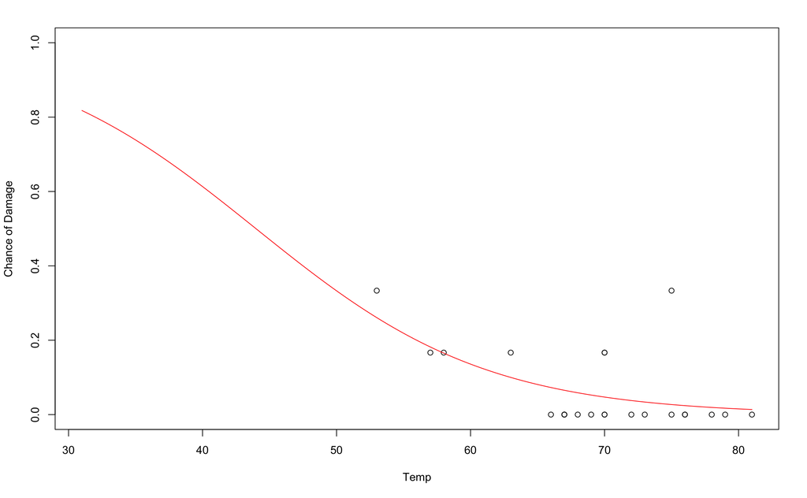

```r
min.temp=31; max.temp=max(orings$temp)
plot(orings$temp, orings$damage/6,
     xlim=c(min.temp, max.temp), ylim=c(0,1),
     xlab="Temp", ylab="Chance of Damage")
newtemp = seq(min.temp, max.temp, length=100)
phat = predict(logitmod, data.frame(temp=newtemp), type="response")
lines(newtemp, phat, col="red")
```